# Risk Factor Analysis

## Outcome Variable

**Outcome Variable:** wasted

## Predictor Variables

**Intervention Variable:** exclfeed3

**Adjustment Set:**

unadjusted

## Stratifying Variables

The analysis was stratified on these variable(s):

- agecat
- studyid
- country

## Data Summary

| agecat | studyid | country | exclfeed3 | wasted | n_cell | n |
| --- | --- | --- | --- | --- | --- | --- |
| Birth | ki0047075b-MAL-ED | BANGLADESH | 0 | 0 | 54 | 227 |
| Birth | ki0047075b-MAL-ED | BANGLADESH | 0 | 1 | 9 | 227 |
| Birth | ki0047075b-MAL-ED | BANGLADESH | 1 | 0 | 135 | 227 |
| Birth | ki0047075b-MAL-ED | BANGLADESH | 1 | 1 | 29 | 227 |
| Birth | ki0047075b-MAL-ED | BRAZIL | 0 | 0 | 108 | 177 |
| Birth | ki0047075b-MAL-ED | BRAZIL | 0 | 1 | 4 | 177 |
| Birth | ki0047075b-MAL-ED | BRAZIL | 1 | 0 | 63 | 177 |
| Birth | ki0047075b-MAL-ED | BRAZIL | 1 | 1 | 2 | 177 |
| Birth | ki0047075b-MAL-ED | INDIA | 0 | 0 | 57 | 193 |
| Birth | ki0047075b-MAL-ED | INDIA | 0 | 1 | 15 | 193 |
| Birth | ki0047075b-MAL-ED | INDIA | 1 | 0 | 103 | 193 |
| Birth | ki0047075b-MAL-ED | INDIA | 1 | 1 | 18 | 193 |
| Birth | ki0047075b-MAL-ED | NEPAL | 0 | 0 | 91 | 166 |
| Birth | ki0047075b-MAL-ED | NEPAL | 0 | 1 | 15 | 166 |
| Birth | ki0047075b-MAL-ED | NEPAL | 1 | 0 | 55 | 166 |
| Birth | ki0047075b-MAL-ED | NEPAL | 1 | 1 | 5 | 166 |
| Birth | ki0047075b-MAL-ED | PERU | 0 | 0 | 195 | 265 |
| Birth | ki0047075b-MAL-ED | PERU | 0 | 1 | 6 | 265 |
| Birth | ki0047075b-MAL-ED | PERU | 1 | 0 | 64 | 265 |
| Birth | ki0047075b-MAL-ED | PERU | 1 | 1 | 0 | 265 |
| Birth | ki0047075b-MAL-ED | SOUTH AFRICA | 0 | 0 | 185 | 231 |
| Birth | ki0047075b-MAL-ED | SOUTH AFRICA | 0 | 1 | 14 | 231 |
| Birth | ki0047075b-MAL-ED | SOUTH AFRICA | 1 | 0 | 32 | 231 |
| Birth | ki0047075b-MAL-ED | SOUTH AFRICA | 1 | 1 | 0 | 231 |
| Birth | ki0047075b-MAL-ED | TANZANIA, UNITED REPUBLIC OF | 0 | 0 | 74 | 114 |
| Birth | ki0047075b-MAL-ED | TANZANIA, UNITED REPUBLIC OF | 0 | 1 | 2 | 114 |
| Birth | ki0047075b-MAL-ED | TANZANIA, UNITED REPUBLIC OF | 1 | 0 | 38 | 114 |
| Birth | ki0047075b-MAL-ED | TANZANIA, UNITED REPUBLIC OF | 1 | 1 | 0 | 114 |
| Birth | ki1000108-CMC-V-BCS-2002 | INDIA | 0 | 0 | 0 | 4 |
| Birth | ki1000108-CMC-V-BCS-2002 | INDIA | 0 | 1 | 0 | 4 |

[output cut: 146 more lines]

The following strata were considered:

- agecat: 24 months, studyid: ki0047075b-MAL-ED, country: BANGLADESH
- agecat: 24 months, studyid: ki0047075b-MAL-ED, country: BRAZIL
- agecat: 24 months, studyid: ki0047075b-MAL-ED, country: INDIA
- agecat: 24 months, studyid: ki0047075b-MAL-ED, country: NEPAL
- agecat: 24 months, studyid: ki0047075b-MAL-ED, country: PERU
- agecat: 24 months, studyid: ki0047075b-MAL-ED, country: SOUTH AFRICA
- agecat: 24 months, studyid: ki0047075b-MAL-ED, country: TANZANIA, UNITED REPUBLIC OF
- agecat: 24 months, studyid: ki1000108-CMC-V-BCS-2002, country: INDIA
- agecat: 24 months, studyid: ki1000108-IRC, country: INDIA
- agecat: 24 months, studyid: ki1017093b-PROVIDE, country: BANGLADESH
- agecat: 24 months, studyid: ki1101329-Keneba, country: GAMBIA
- agecat: 24 months, studyid: ki1113344-GMS-Nepal, country: NEPAL
- agecat: 24 months, studyid: kiGH5241-JiVitA-3, country: BANGLADESH
- agecat: 24 months, studyid: kiGH5241-JiVitA-4, country: BANGLADESH
- agecat: 6 months, studyid: ki0047075b-MAL-ED, country: BANGLADESH
- agecat: 6 months, studyid: ki0047075b-MAL-ED, country: BRAZIL
- agecat: 6 months, studyid: ki0047075b-MAL-ED, country: INDIA
- agecat: 6 months, studyid: ki0047075b-MAL-ED, country: NEPAL
- agecat: 6 months, studyid: ki0047075b-MAL-ED, country: PERU
- agecat: 6 months, studyid: ki0047075b-MAL-ED, country: SOUTH AFRICA
- agecat: 6 months, studyid: ki0047075b-MAL-ED, country: TANZANIA, UNITED REPUBLIC OF
- agecat: 6 months, studyid: ki1000108-CMC-V-BCS-2002, country: INDIA
- agecat: 6 months, studyid: ki1000108-IRC, country: INDIA
- agecat: 6 months, studyid: ki1000109-EE, country: PAKISTAN
- agecat: 6 months, studyid: ki1000304b-SAS-CompFeed, country: INDIA
- agecat: 6 months, studyid: ki1017093b-PROVIDE, country: BANGLADESH
- agecat: 6 months, studyid: ki1101329-Keneba, country: GAMBIA
- agecat: 6 months, studyid: ki1113344-GMS-Nepal, country: NEPAL
- agecat: 6 months, studyid: kiGH5241-JiVitA-3, country: BANGLADESH
- agecat: 6 months, studyid: kiGH5241-JiVitA-4, country: BANGLADESH
- agecat: Birth, studyid: ki0047075b-MAL-ED, country: BANGLADESH
- agecat: Birth, studyid: ki0047075b-MAL-ED, country: BRAZIL
- agecat: Birth, studyid: ki0047075b-MAL-ED, country: INDIA
- agecat: Birth, studyid: ki0047075b-MAL-ED, country: NEPAL
- agecat: Birth, studyid: ki0047075b-MAL-ED, country: PERU
- agecat: Birth, studyid: ki0047075b-MAL-ED, country: SOUTH AFRICA
- agecat: Birth, studyid: ki0047075b-MAL-ED, country: TANZANIA, UNITED REPUBLIC OF
- agecat: Birth, studyid: ki1000108-CMC-V-BCS-2002, country: INDIA
- agecat: Birth, studyid: ki1000108-IRC, country: INDIA
- agecat: Birth, studyid: ki1000109-EE, country: PAKISTAN
- agecat: Birth, studyid: ki1000304b-SAS-CompFeed, country: INDIA
- agecat: Birth, studyid: ki1101329-Keneba, country: GAMBIA
- agecat: Birth, studyid: kiGH5241-JiVitA-3, country: BANGLADESH
- agecat: Birth, studyid: kiGH5241-JiVitA-4, country: BANGLADESH

### Dropped Strata

Some strata were dropped due to rare outcomes:

- agecat: Birth, studyid: ki0047075b-MAL-ED, country: BRAZIL
- agecat: Birth, studyid: ki0047075b-MAL-ED, country: PERU
- agecat: Birth, studyid: ki0047075b-MAL-ED, country: SOUTH AFRICA
- agecat: Birth, studyid: ki0047075b-MAL-ED, country: TANZANIA, UNITED REPUBLIC OF
- agecat: Birth, studyid: ki1000108-CMC-V-BCS-2002, country: INDIA
- agecat: Birth, studyid: ki1000108-IRC, country: INDIA
- agecat: Birth, studyid: ki1000109-EE, country: PAKISTAN
- agecat: Birth, studyid: ki1000304b-SAS-CompFeed, country: INDIA
- agecat: Birth, studyid: kiGH5241-JiVitA-4, country: BANGLADESH
- agecat: 6 months, studyid: ki0047075b-MAL-ED, country: BANGLADESH
- agecat: 6 months, studyid: ki0047075b-MAL-ED, country: BRAZIL
- agecat: 6 months, studyid: ki0047075b-MAL-ED, country: NEPAL
- agecat: 6 months, studyid: ki0047075b-MAL-ED, country: PERU
- agecat: 6 months, studyid: ki0047075b-MAL-ED, country: SOUTH AFRICA
- agecat: 6 months, studyid: ki0047075b-MAL-ED, country: TANZANIA, UNITED REPUBLIC OF
- agecat: 6 months, studyid: ki1000108-CMC-V-BCS-2002, country: INDIA
- agecat: 6 months, studyid: ki1000108-IRC, country: INDIA
- agecat: 6 months, studyid: ki1000304b-SAS-CompFeed, country: INDIA
- agecat: 6 months, studyid: kiGH5241-JiVitA-4, country: BANGLADESH
- agecat: 24 months, studyid: ki0047075b-MAL-ED, country: BANGLADESH
- agecat: 24 months, studyid: ki0047075b-MAL-ED, country: BRAZIL
- agecat: 24 months, studyid: ki0047075b-MAL-ED, country: NEPAL
- agecat: 24 months, studyid: ki0047075b-MAL-ED, country: PERU
- agecat: 24 months, studyid: ki0047075b-MAL-ED, country: SOUTH AFRICA
- agecat: 24 months, studyid: ki0047075b-MAL-ED, country: TANZANIA, UNITED REPUBLIC OF
- agecat: 24 months, studyid: ki1000108-CMC-V-BCS-2002, country: INDIA
- agecat: 24 months, studyid: ki1000108-IRC, country: INDIA
- agecat: 24 months, studyid: kiGH5241-JiVitA-4, country: BANGLADESH

## Methods Detail

We’re interested in the causal parameters $E[Y_a]$ for all values of $a \in \mathcal{A}$. These parameters represent the mean outcome if, possibly contrary to fact, we intervened to set all units to have $A=a$. Under the randomization and positivity assumptions, these are identified by the statistical parameters $\psi_a=E_W[E_{Y|A,W}(Y|A=a,W)]$. In addition, we’re interested in the mean of $Y$, $E[Y]$ under no intervention (the observed mean). We will estimate these parameters by using SuperLearner to fit the relevant likelihood factors – $E_{Y|A,W}(Y|A=a,W)$ and $p(A=a|W)$, and then updating our likelihood fit using a joint TMLE.

For unadjusted analyses ($W=\{\}$), initial likelihoods were estimated using Lrnr_glm to estimate the simple $E(Y|A)$ and Lrnr_mean to estimate $p(A)$. For adjusted analyses, a small library containing Lrnr_glmnet, Lrnr_xgboost, and Lrnr_mean was used.

Having estimated these parameters, we will then use the delta method to estimate relative risks and attributable risks relative to a prespecified baseline level of $A$.

# Results Detail

## Results Plots

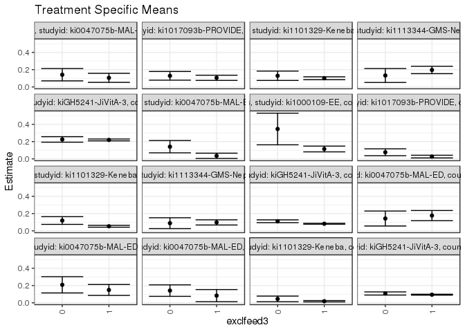

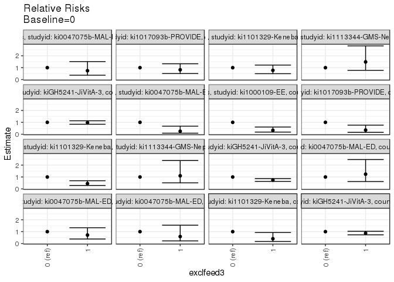

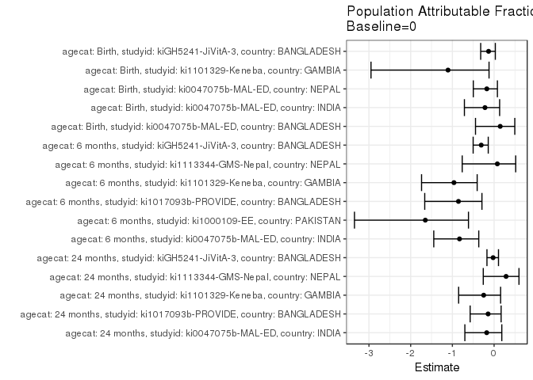

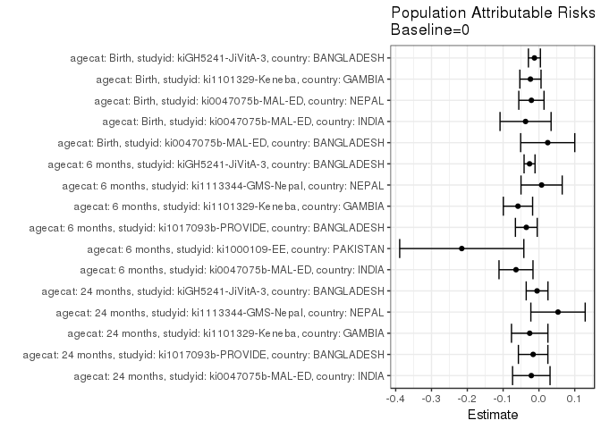

## Results Table

### Parameter: TSM

| agecat | studyid | country | intervention_level | baseline_level | estimate | ci_lower | ci_upper |
| --- | --- | --- | --- | --- | --- | --- | --- |
| Birth | ki0047075b-MAL-ED | BANGLADESH | 0 | NA | 0.1428571 | 0.0562579 | 0.2294564 |
| Birth | ki0047075b-MAL-ED | BANGLADESH | 1 | NA | 0.1768293 | 0.1183089 | 0.2353496 |
| Birth | ki0047075b-MAL-ED | INDIA | 0 | NA | 0.2083333 | 0.1142830 | 0.3023837 |
| Birth | ki0047075b-MAL-ED | INDIA | 1 | NA | 0.1487603 | 0.0851902 | 0.2123304 |
| Birth | ki0047075b-MAL-ED | NEPAL | 0 | NA | 0.1415094 | 0.0749564 | 0.2080624 |
| Birth | ki0047075b-MAL-ED | NEPAL | 1 | NA | 0.0833333 | 0.0131879 | 0.1534788 |
| Birth | ki1101329-Keneba | GAMBIA | 0 | NA | 0.0451613 | 0.0124576 | 0.0778650 |
| Birth | ki1101329-Keneba | GAMBIA | 1 | NA | 0.0182609 | 0.0105194 | 0.0260024 |
| Birth | kiGH5241-JiVitA-3 | BANGLADESH | 0 | NA | 0.1081851 | 0.0899523 | 0.1264179 |
| Birth | kiGH5241-JiVitA-3 | BANGLADESH | 1 | NA | 0.0942393 | 0.0889244 | 0.0995542 |
| 6 months | ki0047075b-MAL-ED | INDIA | 0 | NA | 0.1413043 | 0.0699722 | 0.2126365 |
| 6 months | ki0047075b-MAL-ED | INDIA | 1 | NA | 0.0354610 | 0.0048690 | 0.0660530 |
| 6 months | ki1000109-EE | PAKISTAN | 0 | NA | 0.3461538 | 0.1630432 | 0.5292645 |
| 6 months | ki1000109-EE | PAKISTAN | 1 | NA | 0.1146132 | 0.0811475 | 0.1480788 |
| 6 months | ki1017093b-PROVIDE | BANGLADESH | 0 | NA | 0.0764706 | 0.0364881 | 0.1164531 |
| 6 months | ki1017093b-PROVIDE | BANGLADESH | 1 | NA | 0.0266990 | 0.0111199 | 0.0422782 |
| 6 months | ki1101329-Keneba | GAMBIA | 0 | NA | 0.1194030 | 0.0745624 | 0.1642435 |
| 6 months | ki1101329-Keneba | GAMBIA | 1 | NA | 0.0532122 | 0.0420023 | 0.0644221 |
| 6 months | ki1113344-GMS-Nepal | NEPAL | 0 | NA | 0.0886076 | 0.0258744 | 0.1513408 |
| 6 months | ki1113344-GMS-Nepal | NEPAL | 1 | NA | 0.0976253 | 0.0677111 | 0.1275396 |
| 6 months | kiGH5241-JiVitA-3 | BANGLADESH | 0 | NA | 0.1110368 | 0.0948820 | 0.1271915 |
| 6 months | kiGH5241-JiVitA-3 | BANGLADESH | 1 | NA | 0.0821927 | 0.0770947 | 0.0872907 |
| 24 months | ki0047075b-MAL-ED | INDIA | 0 | NA | 0.1413043 | 0.0699667 | 0.2126420 |
| 24 months | ki0047075b-MAL-ED | INDIA | 1 | NA | 0.1052632 | 0.0529904 | 0.1575359 |
| 24 months | ki1017093b-PROVIDE | BANGLADESH | 0 | NA | 0.1286550 | 0.0784283 | 0.1788816 |
| 24 months | ki1017093b-PROVIDE | BANGLADESH | 1 | NA | 0.1056511 | 0.0757617 | 0.1355405 |
| 24 months | ki1101329-Keneba | GAMBIA | 0 | NA | 0.1292517 | 0.0750008 | 0.1835026 |
| 24 months | ki1101329-Keneba | GAMBIA | 1 | NA | 0.1004710 | 0.0839573 | 0.1169846 |
| 24 months | ki1113344-GMS-Nepal | NEPAL | 0 | NA | 0.1323529 | 0.0517093 | 0.2129966 |
| 24 months | ki1113344-GMS-Nepal | NEPAL | 1 | NA | 0.1964286 | 0.1538951 | 0.2389621 |
| 24 months | kiGH5241-JiVitA-3 | BANGLADESH | 0 | NA | 0.2253350 | 0.1935046 | 0.2571653 |
| 24 months | kiGH5241-JiVitA-3 | BANGLADESH | 1 | NA | 0.2195675 | 0.2087936 | 0.2303415 |

### Parameter: E(Y)

| agecat | studyid | country | intervention_level | baseline_level | estimate | ci_lower | ci_upper |
| --- | --- | --- | --- | --- | --- | --- | --- |
| Birth | ki0047075b-MAL-ED | BANGLADESH | NA | NA | 0.1674009 | 0.1187276 | 0.2160742 |
| Birth | ki0047075b-MAL-ED | INDIA | NA | NA | 0.1709845 | 0.1177299 | 0.2242391 |
| Birth | ki0047075b-MAL-ED | NEPAL | NA | NA | 0.1204819 | 0.0708125 | 0.1701514 |
| Birth | ki1101329-Keneba | GAMBIA | NA | NA | 0.0214559 | 0.0135914 | 0.0293205 |
| Birth | kiGH5241-JiVitA-3 | BANGLADESH | NA | NA | 0.0955338 | 0.0902714 | 0.1007962 |
| 6 months | ki0047075b-MAL-ED | INDIA | NA | NA | 0.0772532 | 0.0428971 | 0.1116093 |
| 6 months | ki1000109-EE | PAKISTAN | NA | NA | 0.1306667 | 0.0965090 | 0.1648243 |
| 6 months | ki1017093b-PROVIDE | BANGLADESH | NA | NA | 0.0412371 | 0.0250690 | 0.0574052 |
| 6 months | ki1101329-Keneba | GAMBIA | NA | NA | 0.0608496 | 0.0496205 | 0.0720787 |
| 6 months | ki1113344-GMS-Nepal | NEPAL | NA | NA | 0.0960699 | 0.0690520 | 0.1230877 |
| 6 months | kiGH5241-JiVitA-3 | BANGLADESH | NA | NA | 0.0848459 | 0.0799494 | 0.0897424 |
| 24 months | ki0047075b-MAL-ED | INDIA | NA | NA | 0.1200000 | 0.0774445 | 0.1625555 |
| 24 months | ki1017093b-PROVIDE | BANGLADESH | NA | NA | 0.1124567 | 0.0866788 | 0.1382347 |
| 24 months | ki1101329-Keneba | GAMBIA | NA | NA | 0.1034483 | 0.0876083 | 0.1192882 |
| 24 months | ki1113344-GMS-Nepal | NEPAL | NA | NA | 0.1856436 | 0.1476821 | 0.2236050 |
| 24 months | kiGH5241-JiVitA-3 | BANGLADESH | NA | NA | 0.2201371 | 0.2099559 | 0.2303184 |

### Parameter: RR

| agecat | studyid | country | intervention_level | baseline_level | estimate | ci_lower | ci_upper |
| --- | --- | --- | --- | --- | --- | --- | --- |
| Birth | ki0047075b-MAL-ED | BANGLADESH | 0 | 0 | 1.0000000 | 1.0000000 | 1.0000000 |
| Birth | ki0047075b-MAL-ED | BANGLADESH | 1 | 0 | 1.2378049 | 0.6204509 | 2.4694313 |
| Birth | ki0047075b-MAL-ED | INDIA | 0 | 0 | 1.0000000 | 1.0000000 | 1.0000000 |
| Birth | ki0047075b-MAL-ED | INDIA | 1 | 0 | 0.7140496 | 0.3834969 | 1.3295201 |
| Birth | ki0047075b-MAL-ED | NEPAL | 0 | 0 | 1.0000000 | 1.0000000 | 1.0000000 |
| Birth | ki0047075b-MAL-ED | NEPAL | 1 | 0 | 0.5888889 | 0.2245312 | 1.5445072 |
| Birth | ki1101329-Keneba | GAMBIA | 0 | 0 | 1.0000000 | 1.0000000 | 1.0000000 |
| Birth | ki1101329-Keneba | GAMBIA | 1 | 0 | 0.4043478 | 0.1747149 | 0.9357939 |
| Birth | kiGH5241-JiVitA-3 | BANGLADESH | 0 | 0 | 1.0000000 | 1.0000000 | 1.0000000 |
| Birth | kiGH5241-JiVitA-3 | BANGLADESH | 1 | 0 | 0.8710936 | 0.7331844 | 1.0349432 |
| 6 months | ki0047075b-MAL-ED | INDIA | 0 | 0 | 1.0000000 | 1.0000000 | 1.0000000 |
| 6 months | ki0047075b-MAL-ED | INDIA | 1 | 0 | 0.2509547 | 0.0923637 | 0.6818509 |
| 6 months | ki1000109-EE | PAKISTAN | 0 | 0 | 1.0000000 | 1.0000000 | 1.0000000 |
| 6 months | ki1000109-EE | PAKISTAN | 1 | 0 | 0.3311047 | 0.1809487 | 0.6058643 |
| 6 months | ki1017093b-PROVIDE | BANGLADESH | 0 | 0 | 1.0000000 | 1.0000000 | 1.0000000 |
| 6 months | ki1017093b-PROVIDE | BANGLADESH | 1 | 0 | 0.3491412 | 0.1594910 | 0.7643034 |
| 6 months | ki1101329-Keneba | GAMBIA | 0 | 0 | 1.0000000 | 1.0000000 | 1.0000000 |
| 6 months | ki1101329-Keneba | GAMBIA | 1 | 0 | 0.4456522 | 0.2897291 | 0.6854880 |
| 6 months | ki1113344-GMS-Nepal | NEPAL | 0 | 0 | 1.0000000 | 1.0000000 | 1.0000000 |
| 6 months | ki1113344-GMS-Nepal | NEPAL | 1 | 0 | 1.1017716 | 0.5093937 | 2.3830305 |
| 6 months | kiGH5241-JiVitA-3 | BANGLADESH | 0 | 0 | 1.0000000 | 1.0000000 | 1.0000000 |
| 6 months | kiGH5241-JiVitA-3 | BANGLADESH | 1 | 0 | 0.7402295 | 0.6329769 | 0.8656551 |
| 24 months | ki0047075b-MAL-ED | INDIA | 0 | 0 | 1.0000000 | 1.0000000 | 1.0000000 |
| 24 months | ki0047075b-MAL-ED | INDIA | 1 | 0 | 0.7449393 | 0.3669230 | 1.5124005 |
| 24 months | ki1017093b-PROVIDE | BANGLADESH | 0 | 0 | 1.0000000 | 1.0000000 | 1.0000000 |
| 24 months | ki1017093b-PROVIDE | BANGLADESH | 1 | 0 | 0.8211972 | 0.5070632 | 1.3299424 |
| 24 months | ki1101329-Keneba | GAMBIA | 0 | 0 | 1.0000000 | 1.0000000 | 1.0000000 |
| 24 months | ki1101329-Keneba | GAMBIA | 1 | 0 | 0.7773279 | 0.4952673 | 1.2200254 |
| 24 months | ki1113344-GMS-Nepal | NEPAL | 0 | 0 | 1.0000000 | 1.0000000 | 1.0000000 |
| 24 months | ki1113344-GMS-Nepal | NEPAL | 1 | 0 | 1.4841270 | 0.7773902 | 2.8333685 |
| 24 months | kiGH5241-JiVitA-3 | BANGLADESH | 0 | 0 | 1.0000000 | 1.0000000 | 1.0000000 |
| 24 months | kiGH5241-JiVitA-3 | BANGLADESH | 1 | 0 | 0.9744051 | 0.8387363 | 1.1320190 |

### Parameter: PAR

| agecat | studyid | country | intervention_level | baseline_level | estimate | ci_lower | ci_upper |
| --- | --- | --- | --- | --- | --- | --- | --- |
| Birth | ki0047075b-MAL-ED | BANGLADESH | 0 | NA | 0.0245437 | -0.0509933 | 0.1000807 |
| Birth | ki0047075b-MAL-ED | INDIA | 0 | NA | -0.0373489 | -0.1086356 | 0.0339378 |
| Birth | ki0047075b-MAL-ED | NEPAL | 0 | NA | -0.0210275 | -0.0562363 | 0.0141813 |
| Birth | ki1101329-Keneba | GAMBIA | 0 | NA | -0.0237054 | -0.0533249 | 0.0059142 |
| Birth | kiGH5241-JiVitA-3 | BANGLADESH | 0 | NA | -0.0126512 | -0.0294167 | 0.0041142 |
| 6 months | ki0047075b-MAL-ED | INDIA | 0 | NA | -0.0640511 | -0.1114896 | -0.0166127 |
| 6 months | ki1000109-EE | PAKISTAN | 0 | NA | -0.2154872 | -0.3888274 | -0.0421470 |
| 6 months | ki1017093b-PROVIDE | BANGLADESH | 0 | NA | -0.0352335 | -0.0656657 | -0.0048013 |
| 6 months | ki1101329-Keneba | GAMBIA | 0 | NA | -0.0585534 | -0.0994528 | -0.0176539 |
| 6 months | ki1113344-GMS-Nepal | NEPAL | 0 | NA | 0.0074623 | -0.0500510 | 0.0649755 |
| 6 months | kiGH5241-JiVitA-3 | BANGLADESH | 0 | NA | -0.0261909 | -0.0414583 | -0.0109235 |
| 24 months | ki0047075b-MAL-ED | INDIA | 0 | NA | -0.0213043 | -0.0736332 | 0.0310245 |
| 24 months | ki1017093b-PROVIDE | BANGLADESH | 0 | NA | -0.0161982 | -0.0573630 | 0.0249665 |
| 24 months | ki1101329-Keneba | GAMBIA | 0 | NA | -0.0258034 | -0.0766476 | 0.0250408 |
| 24 months | ki1113344-GMS-Nepal | NEPAL | 0 | NA | 0.0532906 | -0.0225725 | 0.1291537 |
| 24 months | kiGH5241-JiVitA-3 | BANGLADESH | 0 | NA | -0.0051978 | -0.0355602 | 0.0251646 |

### Parameter: PAF

| agecat | studyid | country | intervention_level | baseline_level | estimate | ci_lower | ci_upper |
| --- | --- | --- | --- | --- | --- | --- | --- |
| Birth | ki0047075b-MAL-ED | BANGLADESH | 0 | NA | 0.1466165 | -0.4457968 | 0.4962893 |
| Birth | ki0047075b-MAL-ED | INDIA | 0 | NA | -0.2184343 | -0.7116697 | 0.1326701 |
| Birth | ki0047075b-MAL-ED | NEPAL | 0 | NA | -0.1745283 | -0.4985637 | 0.0794407 |
| Birth | ki1101329-Keneba | GAMBIA | 0 | NA | -1.1048387 | -2.9509798 | -0.1213284 |
| Birth | kiGH5241-JiVitA-3 | BANGLADESH | 0 | NA | -0.1324267 | -0.3212801 | 0.0294335 |
| 6 months | ki0047075b-MAL-ED | INDIA | 0 | NA | -0.8291063 | -1.4462197 | -0.3676735 |
| 6 months | ki1000109-EE | PAKISTAN | 0 | NA | -1.6491366 | -3.3474119 | -0.6142765 |
| 6 months | ki1017093b-PROVIDE | BANGLADESH | 0 | NA | -0.8544118 | -1.6629351 | -0.2913732 |
| 6 months | ki1101329-Keneba | GAMBIA | 0 | NA | -0.9622641 | -1.7390152 | -0.4057901 |
| 6 months | ki1113344-GMS-Nepal | NEPAL | 0 | NA | 0.0776755 | -0.7645088 | 0.5178927 |
| 6 months | kiGH5241-JiVitA-3 | BANGLADESH | 0 | NA | -0.3086881 | -0.5020657 | -0.1402062 |
| 24 months | ki0047075b-MAL-ED | INDIA | 0 | NA | -0.1775362 | -0.7008402 | 0.1847608 |
| 24 months | ki1017093b-PROVIDE | BANGLADESH | 0 | NA | -0.1440396 | -0.5739721 | 0.1684563 |
| 24 months | ki1101329-Keneba | GAMBIA | 0 | NA | -0.2494331 | -0.8500584 | 0.1561980 |
| 24 months | ki1113344-GMS-Nepal | NEPAL | 0 | NA | 0.2870588 | -0.2596402 | 0.5964839 |
| 24 months | kiGH5241-JiVitA-3 | BANGLADESH | 0 | NA | -0.0236117 | -0.1712906 | 0.1054475 |